# Part I - (Dataset Exploration of Fordgobike Share Trip in San Francisco)

## Observation:

##### From my observation so far, little count of occation that bike are shared for all the trip. That is 157606 ocacation, bike are not share for all the trip but 17346 of the occation is when bike is only shared through all the trip

## Question:

##### When are most trip taken?

```python
#checking the start time counts
fordgobike_clean['start_time'].value_counts()
```

[output not shown]

## Visualization:

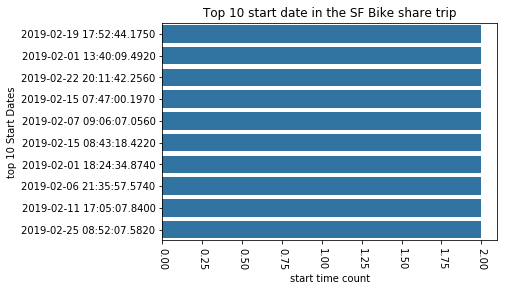

```python
# plooting a bar chart of the start time
base_color = sb.color_palette()[0]
startdate_top10 = fordgobike_clean.start_time.value_counts()[:10].index
sb.countplot(data = fordgobike_clean, y = 'start_time', color = base_color, order = startdate_top10)
plt.xticks(rotation = 270)
plt.ylabel('top 10 Start Dates')
plt.xlabel('start time count')
plt.title('Top 10 start date in the SF Bike share trip');
```

## Observation:

> **Rubric Tip**: Visualizations should depict the data appropriately so that the plots are easily interpretable. You should choose an appropriate plot type, data encodings, and formatting as needed. The formatting may include setting/adding the title, labels, legend, and comments. Also, do not overplot or incorrectly plot ordinal data.

### Discuss the distribution(s) of your variable(s) of interest. Were there any unusual points? Did you need to perform any transformations?

> My main focus on this section to explore some the Numerial and categorial variables like Duration_sec, Age, Start_time, Start_station_name, End_station_name, age_group, bike_share_for_all_trip, user_type and member_gender. I explored them base on their counts and category counts. I aslo trnasform year to age by scrapping.

### Of the features you investigated, were there any unusual distributions? Did you perform any operations on the data to tidy, adjust, or change the form of the data? If so, why did you do this?

> I have to drop all the missing values which i did in my data wrangling proocess, also convert year columns to age and categorizing age into age group to get the actual age position

## Bivariate Exploration

> In this section, investigate relationships between pairs of variables in your data. Make sure the variables that you cover here have been introduced in some fashion in the previous section (univariate exploration).

## Question:

### How does age depend on how fast the riders finish the trip?

## Visualization:

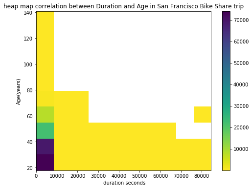

```python
#plotting a heap map of age against duration in second
plt.figure(figsize = [8, 6])
plt.hist2d(data = fordgobike_clean, x = 'duration_sec', y = 'Age', cmin = 0.5, cmap = 'viridis_r');
plt.colorbar()

plt.ylabel('Age(years)')
plt.xlabel(' duration seconds')
plt.title('heap map correlation between Duration and Age in San Francisco Bike Share trip')
plt.show()
```

## Visualization:

[figure not shown]

```python
# plotting a scattered plot of age against the duration time
plt.figure(figsize = [8, 6])
plt.scatter(data = fordgobike_clean, x = 'duration_sec', y = 'Age', alpha = 1/10);
plt.yticks([15, 25, 30, 45, 80], ['15yrs', '25yrs', '30yrs', '45yrs', '80yrs'])
plt.xlabel('Count of duration time in seconds')
plt.ylabel('Age (years)')
plt.title('Scatter plot corrolation of Age and duration time in San Francisco Bike Share');
```

## Observation:

##### The corrolation of the plot is higher at the age 18years to 45year.

## Question:

### How does the member gender affect the changes in the duration time in second

## Visualization:

```
Text(0.5,1,'Violin plot of duration time against member gender of San Francisco Bike Share')
```

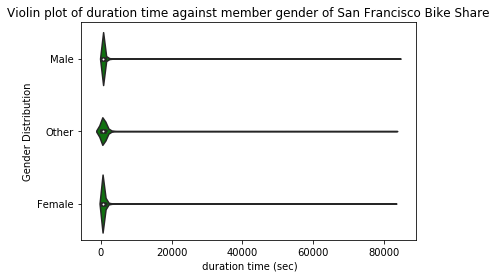

```python
#a violin plot of duration and the member gender
sb.violinplot(data = fordgobike_clean, x = 'duration_sec', y = 'member_gender', color = 'green');
#plt.ylim()
plt.ylabel('Gender Distribution')
plt.xlabel(' duration time (sec)')
plt.title('Violin plot of duration time against member gender of San Francisco Bike Share')
```

## Visualization:

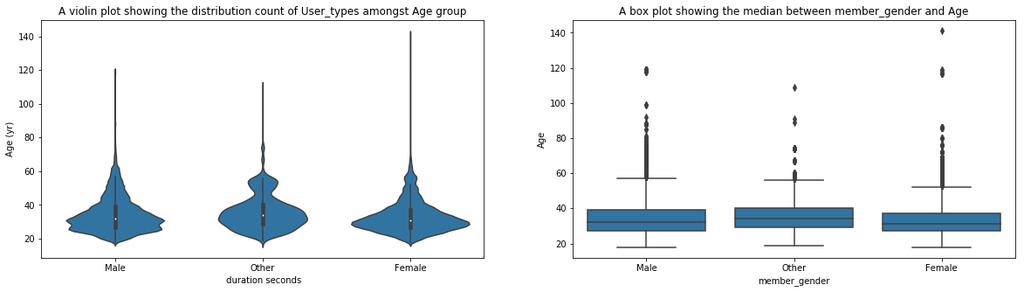

```python
#plotting both the violin plot and the box plot side by side
plt.figure(figsize = [20, 5])
plt.subplot(1, 2, 1)
base_color = sb.color_palette()[0]
sb.violinplot(data = fordgobike_clean, x = 'member_gender', y = 'Age', color = base_color);

plt.ylabel('Age (yr)')
plt.xlabel(' duration seconds')
plt.title('A violin plot showing the distribution count of User_types amongst Age group');
#plot a boxplot for correlation between age and member gender in the SF Bike share data
plt.subplot(1, 2, 2)
base_color = sb.color_palette()[0]
sb.boxplot(data=fordgobike_clean, x = 'member_gender', y = 'Age', color=base_color);
xlabel=('member_gender')
ylabel=('Age (yr)')
plt.title('A box plot showing the median between member_gender and Age' );
plt.show()
```

## Observation:

##### Fom my observation, i have seen that the female among the genders have the oldest rider in the bike share, while the other gender have the lowest riders

## Question:

### How does the age group affect or related to the user type

## Visualization:

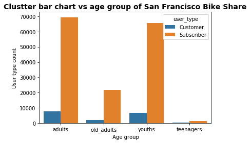

```python
#plotting a cluster bar chart to show the relationship between age group and user type
sb.countplot(data = fordgobike_clean, x = 'age_groups', hue = 'user_type')
plt.ylabel('User type count')
plt.xlabel(' Age group')
plt.title('Clustter bar chart vs age group of San Francisco Bike Share', y = 1, fontsize = 14, weight = "bold");
```

## Observation:

##### The observation shows that Adults are more subscribers followed by the youths, the old_adults before the teenagers.

##### The observation also shows that the adult alos have the highest number of customer, youths have the second highest customer number, followed by old and then finally the teenager.

## Question:

### Does bike share for the trip base on been customer or subscriber?

## Visualization:

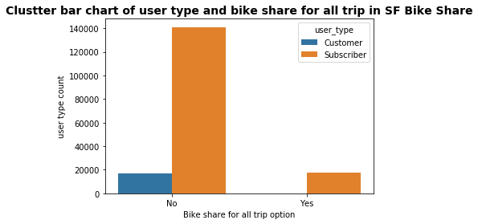

```python
#plotting a cluster bar chart to show the relationship between bike share for all trip and user type
sb.countplot(data = fordgobike_clean, x = 'bike_share_for_all_trip', hue = 'user_type')
plt.xticks(rotation = 0)
plt.ylabel('user type count')
plt.xlabel('Bike share for all trip option')
plt.title('Clustter bar chart of user type and bike share for all trip in SF Bike Share', y = 1, fontsize = 14, weight = "bold");
```

## Question:

### what is the over view structure of the dataset

## Visualization:

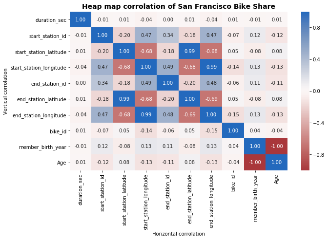

```python
#ploting the corrolation overview of the whole dataset
plt.figure(figsize=(10,6))
sb.heatmap(fordgobike_clean.corr(), annot = True, fmt = '.2f', cmap = 'vlag_r', center = 0)
plt.ylabel('Vertical corrolation')
plt.xlabel('Horizontal corrolation')
plt.title('Heap map corrolation of San Francisco Bike Share', y = 1, fontsize = 14, weight = "bold");
```

## Observation:

### Talk about some of the relationships you observed in this part of the investigation. How did the feature(s) of interest vary with other features in the dataset?

> My main focus on this section to explore some the Numerial and categorial variables like Duration_sec, Age, Start_time, Start_station_name, End_station_name, age_group, bike_share_for_all_trip, user_type and member_gender. I explored on heap map, scatter plot, clustter bar chart, violin and boxplot to show the relationsip between the above variables.

### Did you observe any interesting relationships between the other features (not the main feature(s) of interest)?

> Not on this section but section one(univariate exploration)

## Multivariate Exploration

> Create plots of three or more variables to investigate your data even further. Make sure that your investigations are justified, and follow from your work in the previous sections.

## Visualization:

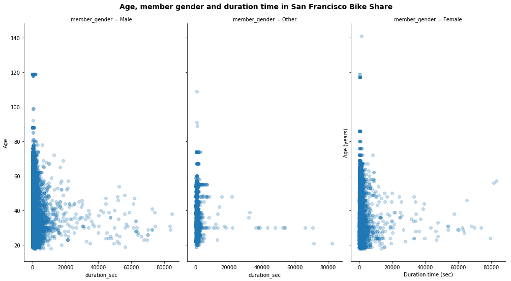

```python
# plotting a facetgrid graph of member gender, duration time in seconds and age
genders = sb.FacetGrid(data = fordgobike_clean, col = 'member_gender',col_wrap = 3, size = 5)
genders.map(plt.scatter, 'duration_sec', 'Age',alpha = 0.25)
genders.fig.set_size_inches(14,8);
plt.ylabel('Age (years)')
plt.xlabel('Duration time (sec)')
plt.suptitle('Age, member gender and duration time in San Francisco Bike Share',y = 1, fontsize = 14, weight = "bold");
plt.show()
```

## Visualization:

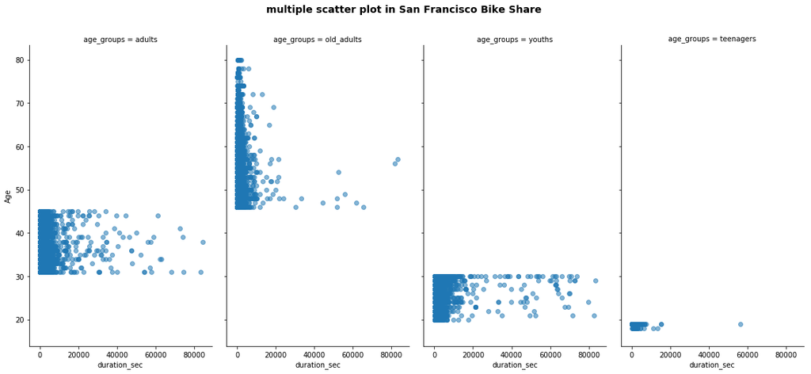

```python
#plotting a facegrid plot

g = sb.FacetGrid(data = fordgobike_clean, col = 'age_groups', size = 3.5,
                margin_titles = True,);
g.map(plt.scatter, 'duration_sec','Age', alpha = 0.55);
g.fig.set_size_inches(16,8);
plt.suptitle('multiple scatter plot in San Francisco Bike Share',y = 1, fontsize = 14, weight = "bold");
plt.show()
```

## Observation:

### Talk about some of the relationships you observed in this part of the investigation. Were there features that strengthened each other in terms of looking at your feature(s) of interest?

> On this section i explore all the variable to see the overview insight of the dataset, expecially the corrolation matrices

### Were there any interesting or surprising interactions between features?

> Not on this section

## Conclusions

> Majority of the riders are of the Age bracket of 18 to 45 years.

> The male gender has the highest population of the users at 74.6% followed by females at 23.3% and other counterparts at 2.1%.

> Market St at 10th St has the highest start count with 3649 start count while San Francisco Caltrain Station 2 (Townsend St at 4th St) have the higest end station name with 4624 end station counts

## Reference

> Udacity.com geeksforgeeks.com stackoverflow.org stack udacity community